# linear_regression

## Energy efficiency Data Set

**Abstract**: This study looked into assessing the heating load and cooling load requirements of buildings (that is, energy efficiency) as a function of building parameters.

**Source**:

The dataset was created by Angeliki Xifara (angxifara'@'gmail.com, Civil/Structural Engineer) and was processed by Athanasios Tsanas (tsanasthanasis'@'gmail.com, Oxford Centre for Industrial and Applied Mathematics, University of Oxford, UK).

A. Tsanas, A. Xifara: 'Accurate quantitative estimation of energy performance of residential buildings using statistical machine learning tools', Energy and Buildings, Vol. 49, pp. 560-567, 2012

**Attribute Information**:

The dataset contains eight attributes (or features, denoted by X1..X8) and two responses denoted by y1 and y2. The aim is to use the eight features to predict each of the two responses.

- X1 `Relative Compactness`
- X2 `Surface Area`
- X3 `Wall Area`
- X4 `Roof Area`
- X5 `Overall Height`
- X6 `Orientation`
- X7 `Glazing Area`
- X8 `Glazing Area Distribution`
- y1 `Heating Load`
- y2 `Cooling Load`

**Imports**:

- Import the dataset into the workspace if it is not already present.
- Import the usual libraries

```python
import os, urllib.request

def get_uci_data(filename, url):
    if not os.path.exists(filename):
        urllib.request.urlretrieve(url, filename)
```

```python
url = "https://archive.ics.uci.edu/ml/machine-learning-databases/00242/ENB2012_data.xlsx"

filename = url.rsplit('/',1)[-1]

get_uci_data(filename, url)
```

```python
import numpy as np
import pandas as pd
import matplotlib.pyplot as plt
import seaborn as sns
```

```python
# !pip install openpyxl
```

```python
df = pd.read_excel(filename)
df.head(1)
```

|  | X1 | X2 | X3 | X4 | X5 | X6 | X7 | X8 | Y1 | Y2 |
| --- | --- | --- | --- | --- | --- | --- | --- | --- | --- | --- |
| 0 | 0.98 | 514.5 | 294.0 | 110.25 | 7.0 | 2 | 0.0 | 0 | 15.55 | 21.33 |

```python
df.dropna(axis=1, inplace=True)
```

```python
columns = ["Relative Compactness", "Surface Area",
"Wall Area", "Roof Area", "Overall Height",
"Orientation", "Glazing Area",
"Glazing Area Distribution", "Heating Load", "Cooling Load"]

df.columns = columns
```

```python
df.head()
```

|  | Relative Compactness | Surface Area | Wall Area | Roof Area | Overall Height | Orientation | Glazing Area | Glazing Area Distribution | Heating Load | Cooling Load |
| --- | --- | --- | --- | --- | --- | --- | --- | --- | --- | --- |
| 0 | 0.98 | 514.5 | 294.0 | 110.25 | 7.0 | 2 | 0.0 | 0 | 15.55 | 21.33 |
| 1 | 0.98 | 514.5 | 294.0 | 110.25 | 7.0 | 3 | 0.0 | 0 | 15.55 | 21.33 |
| 2 | 0.98 | 514.5 | 294.0 | 110.25 | 7.0 | 4 | 0.0 | 0 | 15.55 | 21.33 |
| 3 | 0.98 | 514.5 | 294.0 | 110.25 | 7.0 | 5 | 0.0 | 0 | 15.55 | 21.33 |
| 4 | 0.90 | 563.5 | 318.5 | 122.50 | 7.0 | 2 | 0.0 | 0 | 20.84 | 28.28 |

**Exploratory Data Analysis**

- Get info on the dataframe so far.
  - Check for null values and have a look at the numeral stats
- Get correlation data on the variables and plot as a heatmap
- Create a PartGrid to see any trends between variables
  - NB: This takes a while due to the number of variables. It might be better to construct individual JointGrids instead

```python
df.info()
```

```
<class 'pandas.core.frame.DataFrame'>
RangeIndex: 768 entries, 0 to 767
Data columns (total 10 columns):
 #   Column                     Non-Null Count  Dtype
---  ------                     --------------  -----
 0   Relative Compactness       768 non-null    float64
 1   Surface Area               768 non-null    float64
 2   Wall Area                  768 non-null    float64
 3   Roof Area                  768 non-null    float64
 4   Overall Height             768 non-null    float64
 5   Orientation                768 non-null    int64
 6   Glazing Area               768 non-null    float64
 7   Glazing Area Distribution  768 non-null    int64
 8   Heating Load               768 non-null    float64
 9   Cooling Load               768 non-null    float64
dtypes: float64(8), int64(2)
memory usage: 60.1 KB
```

```python
df.describe().T
```

|  | count | mean | std | min | 25% | 50% | 75% | max |
| --- | --- | --- | --- | --- | --- | --- | --- | --- |
| Relative Compactness | 768.0 | 0.764167 | 0.105777 | 0.62 | 0.6825 | 0.75 | 0.8300 | 0.98 |
| Surface Area | 768.0 | 671.708333 | 88.086116 | 514.50 | 606.3750 | 673.75 | 741.1250 | 808.50 |
| Wall Area | 768.0 | 318.500000 | 43.626481 | 245.00 | 294.0000 | 318.50 | 343.0000 | 416.50 |
| Roof Area | 768.0 | 176.604167 | 45.165950 | 110.25 | 140.8750 | 183.75 | 220.5000 | 220.50 |
| Overall Height | 768.0 | 5.250000 | 1.751140 | 3.50 | 3.5000 | 5.25 | 7.0000 | 7.00 |
| Orientation | 768.0 | 3.500000 | 1.118763 | 2.00 | 2.7500 | 3.50 | 4.2500 | 5.00 |
| Glazing Area | 768.0 | 0.234375 | 0.133221 | 0.00 | 0.1000 | 0.25 | 0.4000 | 0.40 |
| Glazing Area Distribution | 768.0 | 2.812500 | 1.550960 | 0.00 | 1.7500 | 3.00 | 4.0000 | 5.00 |
| Heating Load | 768.0 | 22.307195 | 10.090204 | 6.01 | 12.9925 | 18.95 | 31.6675 | 43.10 |
| Cooling Load | 768.0 | 24.587760 | 9.513306 | 10.90 | 15.6200 | 22.08 | 33.1325 | 48.03 |

```python
correlation = df.corr()
```

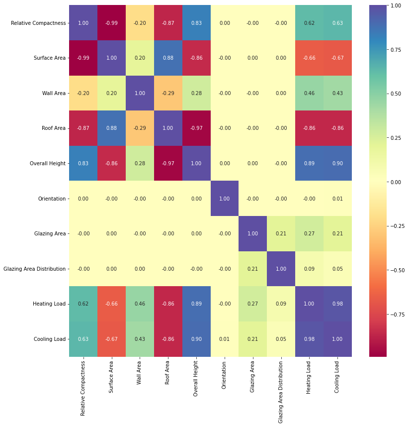

```python
g = sns.FacetGrid(data=correlation, height=12)
g.map_dataframe(sns.heatmap, annot=True, fmt=".2f", cmap="Spectral")
```

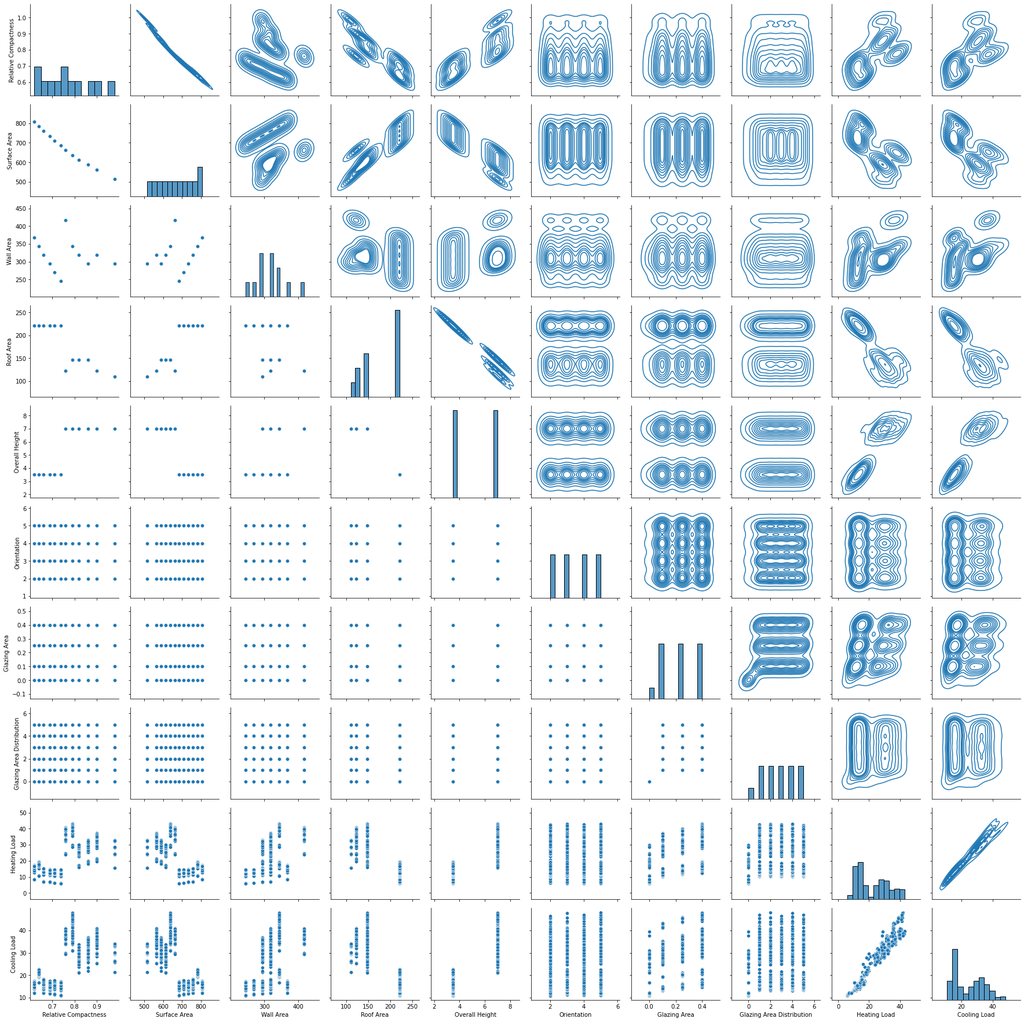

```python
g= sns.PairGrid(data=df)
g.map_diag(sns.histplot)
g.map_lower(sns.scatterplot)
g.map_upper(sns.kdeplot)
```

#### Modeling

1. Create features and target numpy arrays out of the dataframe. Since some Machine Learning Algorithms do not function properly with Pandas dataframes, it is advisable to get into the habit of using Numpy arrays
2. Import relevent ML libraries
3. Split the data into training and test sets
4. Create pipelines to simplify multi-model fitting and evaluation

```python
X = df[["Relative Compactness", "Surface Area", "Roof Area",
        "Overall Height", "Wall Area", "Glazing Area"]].values

y = df[["Heating Load","Cooling Load"]].values
```

```python
type(X)
```

```
numpy.ndarray
```

```python
from sklearn.model_selection import train_test_split
```

```python
X_train, X_test, y_train, y_test = train_test_split(X, y, test_size=0.2, random_state=42)
```

```python
from sklearn.linear_model import LinearRegression
from sklearn.preprocessing import PolynomialFeatures
from sklearn.ensemble import RandomForestRegressor
from sklearn.metrics import mean_absolute_error, mean_squared_error
```

```python
from sklearn.pipeline import Pipeline, make_pipeline
from sklearn.preprocessing import StandardScaler
```

Create 3 pipelines for the three different models under consideration: linear regression, polynomial regression, and random forest regression

```python
ln_pipe = Pipeline([('scaler', StandardScaler()),('lin_reg', LinearRegression())])

pl_pipe = make_pipeline(PolynomialFeatures(degree=2), LinearRegression(fit_intercept = False))

rf_pipe = Pipeline([('scaler', StandardScaler()),('rft_reg', RandomForestRegressor())])
```

```python
pipelines = [ln_pipe, pl_pipe, rf_pipe]
pipe_dict = {0:"Linear Regressor", 1:"Polynomial Regressor", 2:"Random Forest Regressor"}
```

#### Model fitting and evaluation

- Fit all models using a simple loop
- Evaluate each model using a separate loop: obtain the *model accuracy*, *mean absolute error*, and the *mean squared error*

```python
for pipe in pipelines:
    pipe.fit(X_train, y_train)
```

```python
for i, pipe in enumerate(pipelines):
    mae = mean_absolute_error(y_test, pipe.predict(X_test))
    mse = mean_squared_error(y_test, pipe.predict(X_test))

    print(f"{pipe_dict.get(i)} Accuracy: {pipe.score(X_test, y_test):.4f}")
    print(f"{pipe_dict.get(i)} MAE : {mae:.4f}")
    print(f"{pipe_dict.get(i)} MSE : {mse:.4f}\n")
```

```
Linear Regressor Accuracy: 0.9021
Linear Regressor MAE : 2.1824
Linear Regressor MSE : 9.5861

Polynomial Regressor Accuracy: 0.9790
Polynomial Regressor MAE : 0.9779
Polynomial Regressor MSE : 1.9932

Random Forest Regressor Accuracy: 0.9822
Random Forest Regressor MAE : 0.7729
Random Forest Regressor MSE : 1.6599
```

### Model Persistence

Save trained models so that they don't have to be retrained every time.

```python
from joblib import dump, load

for i, model in  enumerate(pipelines):
    dump(model, f"{pipe_dict.get(i).replace(' ','_')}.joblib")
```

```python
new_linear_reg = load('Linear_Regressor.joblib')
```

```python
# new_linear_reg.predict(X_test)
```

[figure not shown]

Created in Deepnote